# Random Forest

Example: Species presence with four predictors

Prepared by: Sebastián Escobar-Alonso

A random forest is a supervised machine learning method. For this example, we train it on sites where we already know whether the species is present, and then we use it to predict presence at new sites.

## Simulated field data

We simulate 300 field sites. At each site, we simulated four variables and recorded whether the species was present. Because we invent the data, **we know the true species niche**:

- **Temperature**: the species prefers about 15 °C (hump-shaped effect).
- **Rainfall**: more rain is better (linear effect).
- **Soil pH**: the species prefers a pH around 6.5 (hump-shaped effect).
- **Slope**: has **no effect at all**. It is a decoy variable.

All of this is done to create a dataset to work with.

```r
n     <- 300
temp  <- runif(n, 5, 25)       # mean annual temperature (°C)
rain  <- runif(n, 200, 1500)   # annual rainfall (mm)
ph    <- runif(n, 4.5, 8.5)    # soil pH
slope <- runif(n, 0, 40)       # slope (degrees): NO effect on the species

  # truth: score = how good the site is for the species
  score <- 3 -
    ((temp - 15) / 4)^2 +        # temperature: best at 15 °C
    (rain - 800) / 300 -         # rainfall: more is better
    ((ph - 6.5) / 1)^2           # soil pH: best at 6.5
                                 # slope does not appear: it has no effect

prob    <- 1 / (1 + exp(-score))   # logistic function: score -> probability
present <- rbinom(n, 1, prob)      # draw presence/absence with that probability

sites <- data.frame(temp, rain, ph, slope,
                    species = factor(present, levels = c(0, 1),
                                     labels = c("No", "Yes")))
table(sites$species)   # check the balance
```

```
##
##  No Yes
## 164 136
```

```r
head(sites, 30)
```

```
##         temp      rain       ph     slope species
## 1  23.296121  828.8986 6.492626  3.845892      No
## 2  23.741508  777.9404 5.631057  1.476129      No
## 3  10.722791  278.5013 7.605780 16.037605      No
## 4  21.608953  625.7578 5.715411  0.461489      No
## 5  17.834910 1341.9578 6.562205 22.715641     Yes
## 6  15.381919 1409.7864 6.411803 37.797997     Yes
## 7  19.731766  709.8320 7.575409 13.732087      No
## 8   7.693332  406.5008 5.155715  9.779931      No
## 9  18.139846  615.9319 6.267097 21.667079     Yes
## 10 19.101296  599.0553 6.593631  4.708175     Yes
## 11 14.154836  340.1546 6.407677 14.996338      No
## 12 19.382245 1473.1346 6.598573 13.100445     Yes
## 13 23.693445  845.9745 7.240913 37.888230      No
## 14 10.108576  320.9971 5.907168 36.422996      No
```

[output cut: 16 more lines]

The following plots show the exact theoretical relationship between environmental variables and site suitability. This represents the underlying ‘biological truth’ that our Random Forest model will attempt to uncover from the observed data

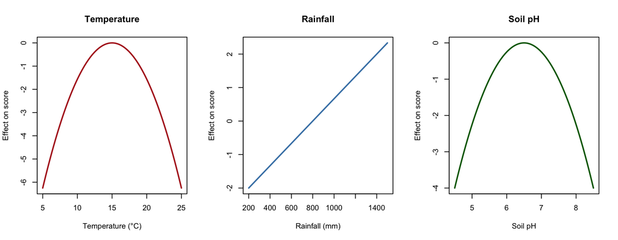

```r
par(mfrow = c(1, 3))

t_seq <- seq(5, 25, length.out = 100)
plot(t_seq, -((t_seq - 15) / 4)^2, type = "l", lwd = 2, col = "firebrick",
     xlab = "Temperature (°C)", ylab = "Effect on score",
     main = "Temperature")


r_seq <- seq(200, 1500, length.out = 100)
plot(r_seq, (r_seq - 800) / 300, type = "l", lwd = 2, col = "steelblue",
     xlab = "Rainfall (mm)", ylab = "Effect on score",
     main = "Rainfall")


p_seq <- seq(4.5, 8.5, length.out = 100)
plot(p_seq, -((p_seq - 6.5) / 1)^2, type = "l", lwd = 2, col = "darkgreen",
     xlab = "Soil pH", ylab = "Effect on score",
     main = "Soil pH")
```

```r
par(mfrow = c(1, 1))
```

Slope has no curve because its true effect is zero.

## One decision tree

A decision tree is a chain of yes/no questions. This tree is pretty unstable: small changes in the data can change the questions. Let’s see it:

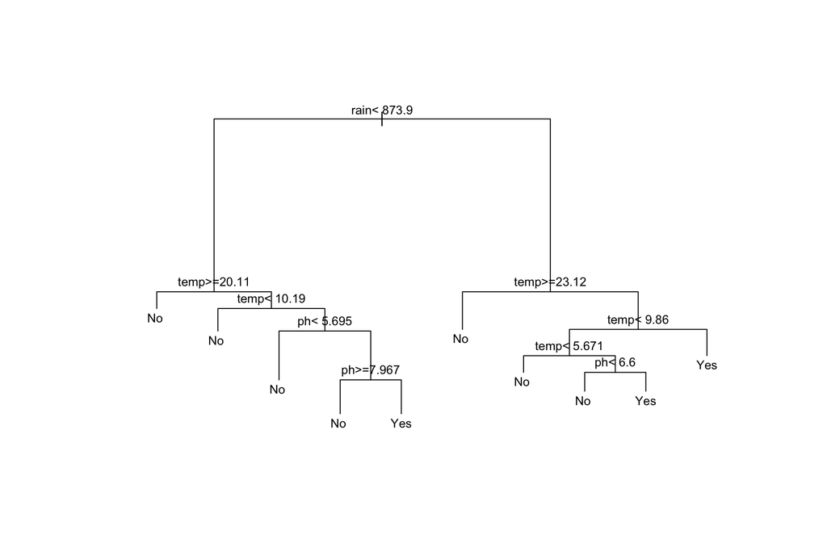

```r
tree <- rpart(species ~ temp + rain + ph + slope, data = sites)
#Fits a single decision tree model using the CART algorithm to predict species presence/absence.
plot(tree,
     uniform = FALSE,
     margin = 0.1)

text(tree, cex = 0.8)
```

Let’s Walk Through the Decision Tree.

- First things first: in this tree, **going left means the condition is met!**
- The big question is all about **precipitation**:
- **Left:** places where `rain < 873.9 mm` (less water available)
- **Right:** places where `rain >= 873.9 mm` (more water available)

### Left side: less water availability

Here, water is limited, so things get picky:

1. `temp >= 20.11` → **No** (too hot and not enough water)
2. Otherwise, `temp < 10.19` → **No** (too cold)
3. If the temperature is between ~10.2 and ~20.1 °C, we check the soil pH:
   - `ph < 5.695` → **No** (soil too acidic)
   - Otherwise, `ph >= 7.967` → **No** (soil too alkaline)
   - **Yes** only if pH is between ~5.7 and ~7.97

### Right side: more water availability

With plenty of water, conditions are a lot more relax:

1. `temp >= 23.12` → **No** (too hot)
2. Otherwise, we check `temp < 9.86`:
   - If that’s **not** true (`temp >= 9.86`) → **Yes** (the simplest path in the whole tree!)
   - If it **is** true (`temp < 9.86`), we fine-tune:
     - `temp < 5.671` → **No** (too cold)
     - Otherwise (temp between 5.67 and 9.86), we check `ph < 6.6`:
       - Lower pH → **No**
       - Higher pH → **Yes**

### Quick summary: when do we get a “Yes”?

**Low rainfall** `rain < 873.9`, `10.19 <= temp < 20.11` and `5.7 <= ph < 7.97` **High rainfall, moderate temperature** `rain >= 873.9` and `9.86 <= temp < 23.12` **High rainfall, mildly cold** `rain >= 873.9`, `5.67 <= temp < 9.86` and `ph >= 6.6`

### Takeaway

Water is the main driver. With more rain, a wider range of temperatures works. With less rain, we need the “just right” combo of mild temperatures **and** near-neutral soil pH.

## Why one tree is not enough?

To see how unstable a single tree can be, we trained four trees. Each one used 270 of the 300 sites, with 30 sites left out at random each time.

The four datasets are almost identical, yet the trees come out different.

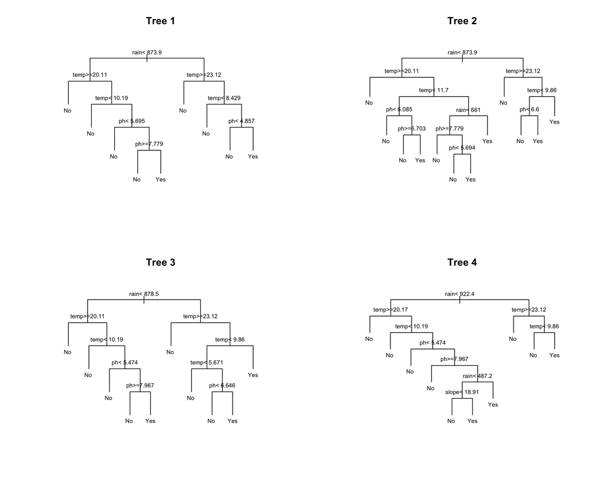

```r
par(mfrow = c(2, 2))

for (i in 1:4) {
  keep <- sample(nrow(sites), 270)   # drop 30 random sites
  t_i  <- rpart(species ~ temp + rain + ph + slope, data = sites[keep, ])
  plot(t_i, uniform = TRUE, margin = 0.1)
  text(t_i, cex = 0.7)
  title(paste("Tree", i))
}
```

```r
par(mfrow = c(1, 1))
```

A single tree depends heavily on which sites happened to end up in the sample, so small changes in the data can change its splits. That is why we use a forest: by combining many trees, the individual quirks average out and the predictions become more stable.

## Random forest

### How the forest works

- We grew 500 trees.
- Each tree is trained on its own random sample of the sites.
- Sites are drawn one at a time **with replacement**, so the same site can show up more than once.
- Each tree learns from about ~63% of the sites.
- The other ~37% are hidden from that tree, so we use them as a test.

```r
rf <- randomForest(species ~ temp + rain + ph + slope, data = sites,
                   ntree    = 500,           # number of trees to grow
                   mtry     = 2,             # sqrt(4)
                   replace  = TRUE,
                   sampsize = nrow(sites),   # 300
                   importance = TRUE)
print(rf)
```

```
##
## Call:
##  randomForest(formula = species ~ temp + rain + ph + slope, data = sites,      ntree = 500, mtry = 2, replace = TRUE, sampsize = nrow(sites),      importance = TRUE)
##                Type of random forest: classification
##                      Number of trees: 500
## No. of variables tried at each split: 2
##
##         OOB estimate of  error rate: 19.33%
## Confusion matrix:
##      No Yes class.error
## No  139  25   0.1524390
## Yes  33 103   0.2426471
```

### How we get the error, in four steps

1. Each tree studies with about 63% of the sites.
2. Each site is a “surprise exam” for about 185 trees (500 trees x 0.37 = 185). 3.Those trees vote Yes or No.
3. We compare the vote with reality for all 300 sites: 58 mistakes, so the error is 19.33%.

The forest is wrong for about 19% of the sites. This is the OOB (out-of-bag) error.

### Does the error stabilize with more trees?

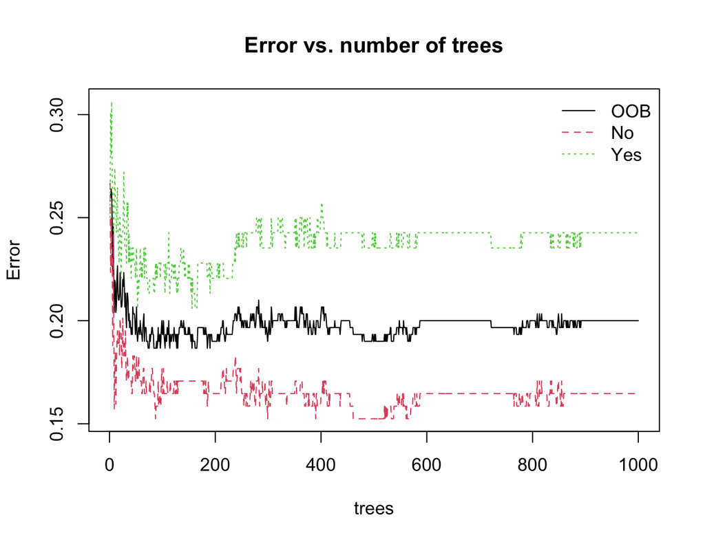

```r
rf2 <- randomForest(species ~ temp + rain + ph + slope, data = sites,
                   ntree    = 1000,           # number of trees to grow
                   mtry     = 2,             # sqrt(4)
                   replace  = TRUE,
                   sampsize = nrow(sites),
                   importance = TRUE)


plot(rf2, main = "Error vs. number of trees")
legend("topright", colnames(rf$err.rate),
       col = 1:3, lty = 1:3, bty = "n")
```

After a couple of hundred trees the error stops changing, so 500 is enough.

In R, the randomForest package uses 500 trees by default (ntree = 500). In Python, scikit-learn uses 100 trees by default (n_estimators = 100).

### What does `mtry` do?

```r
oob_by_mtry <- sapply(1:4, function(m) {
  fit <- randomForest(species ~ temp + rain + ph + slope,
                      data = sites,
                      ntree = 500,
                      mtry = m)
  fit$err.rate[500, "OOB"]
})

data.frame(mtry = 1:4, OOB_error = round(oob_by_mtry, 3))
```

```
##   mtry OOB_error
## 1    1     0.187
## 2    2     0.207
## 3    3     0.193
## 4    4     0.203
```

With `mtry = 4`, every split can use all variables, so the trees look more alike. With `mtry = 1`, each split uses a single random variable, so the trees are very different.

The differences in this exercise are small because mtry becomes more important when there are many more variables.

## Variable importance

Importance measures how much the accuracy drops when we shuffle one variable. If shuffling it makes the model much worse, that variable mattered.

```r
imp <- as.data.frame(importance(rf))
imp$variable <- rownames(imp)
imp[order(-imp$MeanDecreaseAccuracy), c("variable", "MeanDecreaseAccuracy")]
```

```
##       variable MeanDecreaseAccuracy
## temp      temp            48.291689
## rain      rain            41.235631
## ph          ph            23.026553
## slope    slope            -3.595471
```

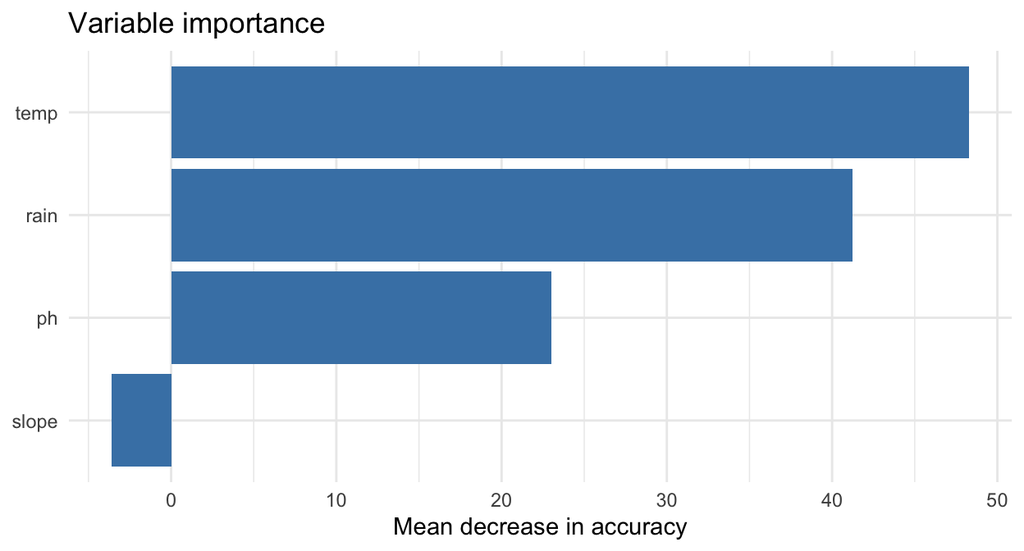

```r
ggplot(imp, aes(x = reorder(variable, MeanDecreaseAccuracy),
                y = MeanDecreaseAccuracy)) +
  geom_col(fill = "steelblue") +
  coord_flip() +
  labs(title = "Variable importance",
       x = NULL, y = "Mean decrease in accuracy") +
  theme_minimal()
```

The plot shows how much the forest gets worse when we shuffle each variable. Temperature and rainfall matter the most, pH matters somewhat less, and slope sits at zero.

That matches what we built into the data: temperature, rainfall and pH affect the species, and slope doesn’t. The forest figured this out on its own.

Slope even comes out slightly negative. That’s just noise: shuffling it didn’t hurt the model, so the variable wasn’t helping. Look at the ranking rather than the exact numbers.

## Predicting a new site

This is the whole point of using Random Forest: prediction

```r
new_site <- data.frame(temp = 15,
                       rain = 1000,
                       ph = 6.5,
                       slope = 10)
predict(rf,
        new_site,
        type = "prob")
```

```
##      No   Yes
## 1 0.022 0.978
## attr(,"class")
## [1] "matrix" "array"  "votes"
```

```r
bad_site <- data.frame(temp = 24,
                       rain = 300,
                       ph = 8,
                       slope = 10)
predict(rf, bad_site, type = "prob")
```

```
##      No   Yes
## 1 0.986 0.014
## attr(,"class")
## [1] "matrix" "array"  "votes"
```

The output is the proportion of the 500 trees that voted “No” and “Yes”. The “Yes” column is the predicted probability of presence.

## A suitability map

```r
# Function that gives the four variables at any (x = east, y = north) location
env_at <- function(x, y) {
  data.frame(
    temp  = pmin(pmax(22 - 1.6 * y + 1.5 * sin(x), 5), 25),
    rain  = pmin(pmax(300 + 110 * x + 80 * sin(y), 200), 1500),
    ph    = pmin(pmax(6.5 + 1.8 * sin(x / 2.5) * cos(y / 2.5), 4.5), 8.5),
    slope = 20 + 15 * sin(x * y / 8)
  )
}


# grid size = 80 x 80 = 6400
grid <- expand.grid(x = seq(0, 10, length.out = 80),
                    y = seq(0, 10, length.out = 80))
grid <- cbind(grid, env_at(grid$x, grid$y))

# Forest prediction: probability of "Yes" in each cell
grid$forest <- predict(rf, grid[, c("temp", "rain", "ph", "slope")],
                       type = "prob")[, "Yes"]

# The true probability, from the formula we used to simulate the data
grid$truth <- plogis(3 -
                     ((grid$temp - 15) / 4)^2 +
                     (grid$rain - 800) / 300 -
                     ((grid$ph - 6.5) / 1)^2)
```

We can compare the forest’s map with the real one:

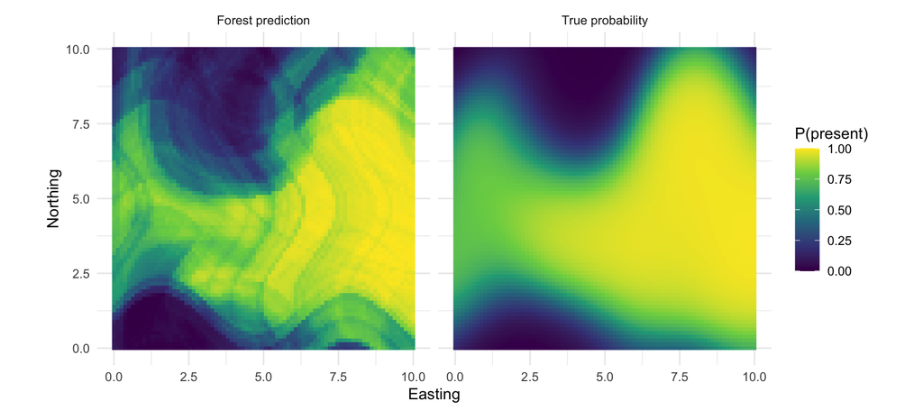

```r
map_long <- rbind(
  data.frame(grid[, c("x", "y")], prob = grid$truth,  map = "True probability"),
  data.frame(grid[, c("x", "y")], prob = grid$forest, map = "Forest prediction")
)

ggplot(map_long, aes(x, y, fill = prob)) +
  geom_raster() +
  facet_wrap(~ map) +
  scale_fill_viridis_c(limits = c(0, 1), name = "P(present)") +
  coord_equal() +
  labs(x = "Easting", y = "Northing") +
  theme_minimal()
```

The forest recovers the main pattern. It looks a bit blocky because it is built from many small step-like splits, while the true surface is smooth.

## Predicting new sites on the map

Now we place eight new sites at random. For each one we get its environmental values, ask the forest for the probability of presence, and plot it on top of the map.

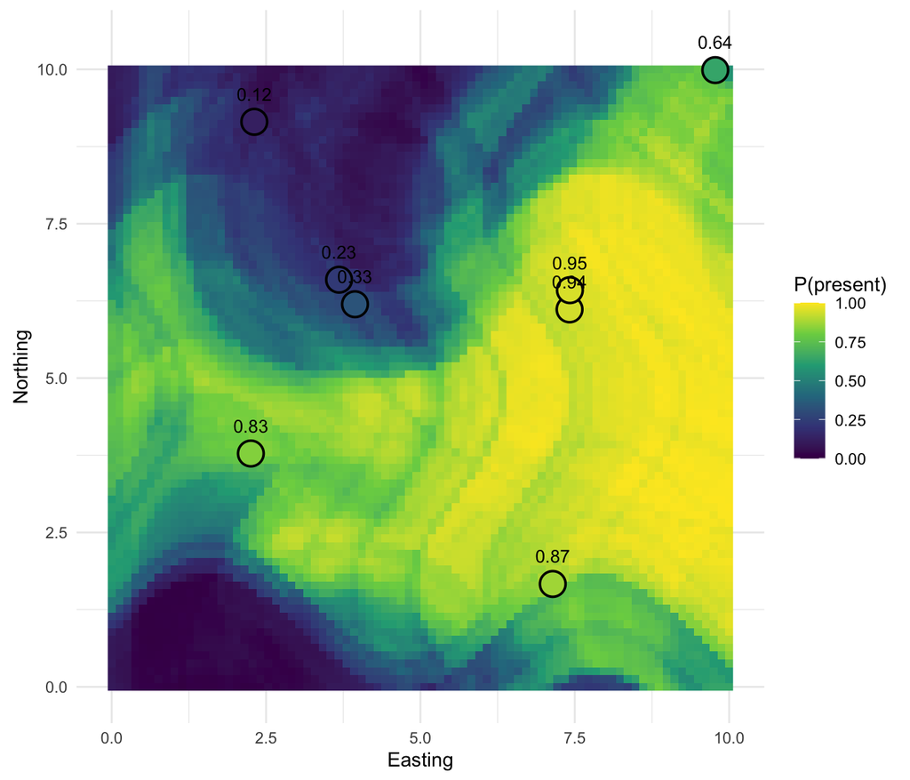

```r
new_sites <- data.frame(x = runif(8, 0, 10),
                        y = runif(8, 0, 10))

new_sites <- cbind(new_sites,
                   env_at(new_sites$x, new_sites$y)
                   )

new_sites$prob <- predict(rf, new_sites[, c("temp", "rain", "ph", "slope")],
                          type = "prob")[, "Yes"]

ggplot() +
  geom_raster(data = grid, aes(x, y, fill = forest)) +
  geom_point(data = new_sites, aes(x, y, fill = prob),
             shape = 21, size = 6, color = "black", stroke = 1) +
  geom_text(data = new_sites, aes(x, y, label = round(prob, 2)),
            nudge_y = 0.45, size = 3.5) +
  scale_fill_viridis_c(limits = c(0, 1), name = "P(present)") +
  coord_equal() +
  labs(x = "Easting", y = "Northing") +
  theme_minimal()
```

```r
new_sites[, c("x", "y", "prob")]
```

```
##          x        y  prob
## 1 9.775145 9.988109 0.640
## 2 7.415026 6.112617 0.940
## 3 2.309088 9.150554 0.124
## 4 3.682018 6.593600 0.230
## 5 3.940115 6.195986 0.332
## 6 7.142802 1.665883 0.870
## 7 2.253389 3.778680 0.832
## 8 7.420457 6.424069 0.948
```

Each circle is a new site, and the number is the proportion of the 500 trees that voted “Yes” there. Sites sitting on bright cells get a high probability, and sites on dark cells get a low one.